# Lab 5: Data Wrangling

Joseph Drake

2/21/2020

## Adding code chunk

use ctr + alt + !

## Accessing data

```r
#Loard Libraries
library(tidyverse)
# Importing from your data directory from within your working directory

SNPs<- read.table("data/23andMe_example_cat25.txt", header = TRUE, sep = "\t")
```

## getting images for RMarkdown

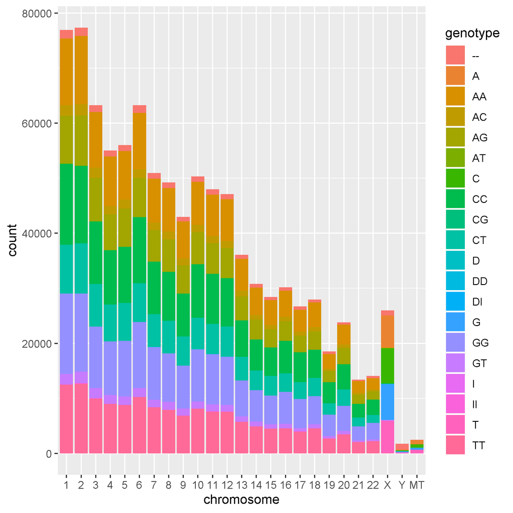

Genotype counts per chromosome

```r
# Importing from your images directory from within your working directory
# This command is put OUTSIDE the r code chunk
```

## getwd()

```r
getwd()
```

```
## [1] "C:/Users/ASUS/Dropbox/Spring2020/Genomics_audit/git-genome-analysis/genome-analysis"
```

Setting up for data carpentry exercises: https://datacarpentry.org/R-ecology-lesson/03-dplyr.html

```r
 download.file(url="https://ndownloader.figshare.com/files/2292169",
              destfile = "data/portal_data_joined.csv")

surveys <- read_csv("data/portal_data_joined.csv")
str(surveys)
```

```
## Classes 'spec_tbl_df', 'tbl_df', 'tbl' and 'data.frame': 34786 obs. of  13 variables:
##  $ record_id      : num  1 72 224 266 349 363 435 506 588 661 ...
##  $ month          : num  7 8 9 10 11 11 12 1 2 3 ...
##  $ day            : num  16 19 13 16 12 12 10 8 18 11 ...
##  $ year           : num  1977 1977 1977 1977 1977 ...
##  $ plot_id        : num  2 2 2 2 2 2 2 2 2 2 ...
##  $ species_id     : chr  "NL" "NL" "NL" "NL" ...
##  $ sex            : chr  "M" "M" NA NA ...
##  $ hindfoot_length: num  32 31 NA NA NA NA NA NA NA NA ...
##  $ weight         : num  NA NA NA NA NA NA NA NA 218 NA ...
##  $ genus          : chr  "Neotoma" "Neotoma" "Neotoma" "Neotoma" ...
##  $ species        : chr  "albigula" "albigula" "albigula" "albigula" ...
##  $ taxa           : chr  "Rodent" "Rodent" "Rodent" "Rodent" ...
##  $ plot_type      : chr  "Control" "Control" "Control" "Control" ...
##  - attr(*, "spec")=
##   .. cols(
##   ..   record_id = col_double(),
##   ..   month = col_double(),
##   ..   day = col_double(),
##   ..   year = col_double(),
##   ..   plot_id = col_double(),
##   ..   species_id = col_character(),
##   ..   sex = col_character(),
##   ..   hindfoot_length = col_double(),
##   ..   weight = col_double(),
##   ..   genus = col_character(),
##   ..   species = col_character(),
##   ..   taxa = col_character(),
##   ..   plot_type = col_character()
##   .. )
```

```r
#View(surveys)
```

```r
select(surveys, plot_id, species_id, weight)
```

```
## # A tibble: 34,786 x 3
##    plot_id species_id weight
##      <dbl> <chr>       <dbl>
##  1       2 NL             NA
##  2       2 NL             NA
##  3       2 NL             NA
##  4       2 NL             NA
##  5       2 NL             NA
##  6       2 NL             NA
##  7       2 NL             NA
##  8       2 NL             NA
##  9       2 NL            218
## 10       2 NL             NA
## # ... with 34,776 more rows
```

```r
#select against certain with (-)
select(surveys, -record_id, -species_id)
```

```
## # A tibble: 34,786 x 11
##    month   day  year plot_id sex   hindfoot_length weight genus species taxa
##    <dbl> <dbl> <dbl>   <dbl> <chr>           <dbl>  <dbl> <chr> <chr>   <chr>
##  1     7    16  1977       2 M                  32     NA Neot~ albigu~ Rode~
##  2     8    19  1977       2 M                  31     NA Neot~ albigu~ Rode~
##  3     9    13  1977       2 <NA>               NA     NA Neot~ albigu~ Rode~
##  4    10    16  1977       2 <NA>               NA     NA Neot~ albigu~ Rode~
##  5    11    12  1977       2 <NA>               NA     NA Neot~ albigu~ Rode~
##  6    11    12  1977       2 <NA>               NA     NA Neot~ albigu~ Rode~
##  7    12    10  1977       2 <NA>               NA     NA Neot~ albigu~ Rode~
##  8     1     8  1978       2 <NA>               NA     NA Neot~ albigu~ Rode~
##  9     2    18  1978       2 M                  NA    218 Neot~ albigu~ Rode~
## 10     3    11  1978       2 <NA>               NA     NA Neot~ albigu~ Rode~
## # ... with 34,776 more rows, and 1 more variable: plot_type <chr>
```

```r
filter(surveys, year==1995)
```

```
## # A tibble: 1,180 x 13
##    record_id month   day  year plot_id species_id sex   hindfoot_length weight
##        <dbl> <dbl> <dbl> <dbl>   <dbl> <chr>      <chr>           <dbl>  <dbl>
##  1     22314     6     7  1995       2 NL         M                  34     NA
##  2     22728     9    23  1995       2 NL         F                  32    165
##  3     22899    10    28  1995       2 NL         F                  32    171
##  4     23032    12     2  1995       2 NL         F                  33     NA
##  5     22003     1    11  1995       2 DM         M                  37     41
##  6     22042     2     4  1995       2 DM         F                  36     45
##  7     22044     2     4  1995       2 DM         M                  37     46
##  8     22105     3     4  1995       2 DM         F                  37     49
##  9     22109     3     4  1995       2 DM         M                  37     46
## 10     22168     4     1  1995       2 DM         M                  36     48
## # ... with 1,170 more rows, and 4 more variables: genus <chr>, species <chr>,
## #   taxa <chr>, plot_type <chr>
```

select() : subset columns filter() : subset rows on conditions mutate() : create new columns by using information from othr columns group_by() and summarize() : create summary stats on grouped data arrange() : sort results count() : count discrete values

## pipes

Want to select and filter at same time?

either: 1.use intermediate steps 2. nested functions 3. PIPES

```r
#intermediate steps can clutter workspace
surveys2 <- filter(surveys, weight < 5)
surveys_sml <- select(surveys2, species_id, sex, weight)


#nested functions can get hard to read
surveys_sml <- select(filter(surveys, weight < 5), species_id, sex, weight)

# piping takes output of one function and sends to next

#use ctrl+shift+m for a pipe

surveys %>%
  filter(weight < 5) %>%
  select(species_id, sex, weight)
```

```
## # A tibble: 17 x 3
##    species_id sex   weight
##    <chr>      <chr>  <dbl>
##  1 PF         F          4
##  2 PF         F          4
##  3 PF         M          4
##  4 RM         F          4
##  5 RM         M          4
##  6 PF         <NA>       4
##  7 PP         M          4
##  8 RM         M          4
##  9 RM         M          4
## 10 RM         M          4
## 11 PF         M          4
## 12 PF         F          4
## 13 RM         M          4
## 14 RM         M          4
## 15 RM         F          4
## 16 RM         M          4
## 17 RM         M          4
```

```r
# can assign it to new object if wanted

surveys_sml <- surveys %>%
  filter(weight < 5) %>%
  select(species_id, sex, weight)

surveys_sml
```

```
## # A tibble: 17 x 3
##    species_id sex   weight
##    <chr>      <chr>  <dbl>
##  1 PF         F          4
##  2 PF         F          4
##  3 PF         M          4
##  4 RM         F          4
##  5 RM         M          4
##  6 PF         <NA>       4
##  7 PP         M          4
##  8 RM         M          4
##  9 RM         M          4
## 10 RM         M          4
## 11 PF         M          4
## 12 PF         F          4
## 13 RM         M          4
## 14 RM         M          4
## 15 RM         F          4
## 16 RM         M          4
## 17 RM         M          4
```

## Mutation Station

To create new column based on existing values

```r
surveys %>%
  mutate(weight_kg= weight/1000)
```

```
## # A tibble: 34,786 x 14
##    record_id month   day  year plot_id species_id sex   hindfoot_length weight
##        <dbl> <dbl> <dbl> <dbl>   <dbl> <chr>      <chr>           <dbl>  <dbl>
##  1         1     7    16  1977       2 NL         M                  32     NA
##  2        72     8    19  1977       2 NL         M                  31     NA
##  3       224     9    13  1977       2 NL         <NA>               NA     NA
##  4       266    10    16  1977       2 NL         <NA>               NA     NA
##  5       349    11    12  1977       2 NL         <NA>               NA     NA
##  6       363    11    12  1977       2 NL         <NA>               NA     NA
##  7       435    12    10  1977       2 NL         <NA>               NA     NA
##  8       506     1     8  1978       2 NL         <NA>               NA     NA
##  9       588     2    18  1978       2 NL         M                  NA    218
## 10       661     3    11  1978       2 NL         <NA>               NA     NA
## # ... with 34,776 more rows, and 5 more variables: genus <chr>, species <chr>,
## #   taxa <chr>, plot_type <chr>, weight_kg <dbl>
```

```r
# or add on using newly created column

surveys %>%
  mutate(weight_kg=weight / 1000,
         weight_lb=weight_kg * 2.2)
```

```
## # A tibble: 34,786 x 15
##    record_id month   day  year plot_id species_id sex   hindfoot_length weight
##        <dbl> <dbl> <dbl> <dbl>   <dbl> <chr>      <chr>           <dbl>  <dbl>
##  1         1     7    16  1977       2 NL         M                  32     NA
##  2        72     8    19  1977       2 NL         M                  31     NA
##  3       224     9    13  1977       2 NL         <NA>               NA     NA
##  4       266    10    16  1977       2 NL         <NA>               NA     NA
##  5       349    11    12  1977       2 NL         <NA>               NA     NA
##  6       363    11    12  1977       2 NL         <NA>               NA     NA
##  7       435    12    10  1977       2 NL         <NA>               NA     NA
##  8       506     1     8  1978       2 NL         <NA>               NA     NA
##  9       588     2    18  1978       2 NL         M                  NA    218
## 10       661     3    11  1978       2 NL         <NA>               NA     NA
## # ... with 34,776 more rows, and 6 more variables: genus <chr>, species <chr>,
## #   taxa <chr>, plot_type <chr>, weight_kg <dbl>, weight_lb <dbl>
```

```r
#works with non-dplyr funcs too
surveys %>%
  mutate(weight_kg = weight / 1000) %>%
  head()
```

```
## # A tibble: 6 x 14
##   record_id month   day  year plot_id species_id sex   hindfoot_length weight
##       <dbl> <dbl> <dbl> <dbl>   <dbl> <chr>      <chr>           <dbl>  <dbl>
## 1         1     7    16  1977       2 NL         M                  32     NA
## 2        72     8    19  1977       2 NL         M                  31     NA
## 3       224     9    13  1977       2 NL         <NA>               NA     NA
## 4       266    10    16  1977       2 NL         <NA>               NA     NA
## 5       349    11    12  1977       2 NL         <NA>               NA     NA
## 6       363    11    12  1977       2 NL         <NA>               NA     NA
## # ... with 5 more variables: genus <chr>, species <chr>, taxa <chr>,
## #   plot_type <chr>, weight_kg <dbl>
```

```r
# or get rid of NA's in weight col
surveys %>%
  filter(!is.na(weight)) %>%
  mutate(weight_kg = weight / 1000) %>%
  head()
```

```
## # A tibble: 6 x 14
##   record_id month   day  year plot_id species_id sex   hindfoot_length weight
##       <dbl> <dbl> <dbl> <dbl>   <dbl> <chr>      <chr>           <dbl>  <dbl>
## 1       588     2    18  1978       2 NL         M                  NA    218
## 2       845     5     6  1978       2 NL         M                  32    204
## 3       990     6     9  1978       2 NL         M                  NA    200
## 4      1164     8     5  1978       2 NL         M                  34    199
## 5      1261     9     4  1978       2 NL         M                  32    197
## 6      1453    11     5  1978       2 NL         M                  NA    218
## # ... with 5 more variables: genus <chr>, species <chr>, taxa <chr>,
## #   plot_type <chr>, weight_kg <dbl>
```

## Split-apply-combine approach

split data into groups, apply analysis to ach group, combine results

Easy(ish) to do with group_by()

```r
surveys %>%
  group_by(sex) %>%
  summarise(mean_weight=mean(weight, na.rm=TRUE))
```

```
## # A tibble: 3 x 2
##   sex   mean_weight
##   <chr>       <dbl>
## 1 F            42.2
## 2 M            43.0
## 3 <NA>         64.7
```

```r
#group by multiple columns
surveys %>%
  group_by(sex, species_id) %>%
  summarise(mean_weight=mean(weight,na.rm = TRUE)) # leaves behind a NaN
```

```
## # A tibble: 92 x 3
## # Groups:   sex [3]
##    sex   species_id mean_weight
##    <chr> <chr>            <dbl>
##  1 F     BA                9.16
##  2 F     DM               41.6
##  3 F     DO               48.5
##  4 F     DS              118.
##  5 F     NL              154.
##  6 F     OL               31.1
##  7 F     OT               24.8
##  8 F     OX               21
##  9 F     PB               30.2
## 10 F     PE               22.8
## # ... with 82 more rows
```

```r
# complete missing value removal
surveys %>%
  filter(!is.na(weight)) %>%
  group_by(sex, species_id) %>%
  summarize(mean_weight = mean(weight))
```

```
## # A tibble: 64 x 3
## # Groups:   sex [3]
##    sex   species_id mean_weight
##    <chr> <chr>            <dbl>
##  1 F     BA                9.16
##  2 F     DM               41.6
##  3 F     DO               48.5
##  4 F     DS              118.
##  5 F     NL              154.
##  6 F     OL               31.1
##  7 F     OT               24.8
##  8 F     OX               21
##  9 F     PB               30.2
## 10 F     PE               22.8
## # ... with 54 more rows
```

```r
surveys %>%
  filter(!is.na(weight)) %>%
  group_by(sex, species_id) %>%
  summarize(mean_weight = mean(weight)) %>%
  print(n = 15)
```

```
## # A tibble: 64 x 3
## # Groups:   sex [3]
##    sex   species_id mean_weight
##    <chr> <chr>            <dbl>
##  1 F     BA                9.16
##  2 F     DM               41.6
##  3 F     DO               48.5
##  4 F     DS              118.
##  5 F     NL              154.
##  6 F     OL               31.1
##  7 F     OT               24.8
##  8 F     OX               21
##  9 F     PB               30.2
## 10 F     PE               22.8
## 11 F     PF                7.97
## 12 F     PH               30.8
## 13 F     PL               19.3
## 14 F     PM               22.1
## 15 F     PP               17.2
## # ... with 49 more rows
```

```r
# summarize multiple variables
surveys %>%
  filter(!is.na(weight)) %>%
  group_by(sex, species_id) %>%
  summarize(mean_weight = mean(weight),
            min_weight = min(weight))
```

```
## # A tibble: 64 x 4
## # Groups:   sex [3]
##    sex   species_id mean_weight min_weight
##    <chr> <chr>            <dbl>      <dbl>
##  1 F     BA                9.16          6
##  2 F     DM               41.6          10
##  3 F     DO               48.5          12
##  4 F     DS              118.           45
##  5 F     NL              154.           32
##  6 F     OL               31.1          10
##  7 F     OT               24.8           5
##  8 F     OX               21            20
##  9 F     PB               30.2          12
## 10 F     PE               22.8          11
## # ... with 54 more rows
```

```r
# arrange results based on created variable

surveys %>%
  filter(!is.na(weight)) %>%
  group_by(sex, species_id) %>%
  summarize(mean_weight = mean(weight),
            min_weight = min(weight)) %>%
  arrange(min_weight)
```

```
## # A tibble: 64 x 4
## # Groups:   sex [3]
##    sex   species_id mean_weight min_weight
##    <chr> <chr>            <dbl>      <dbl>
##  1 F     PF                7.97          4
##  2 F     RM               11.1           4
##  3 M     PF                7.89          4
##  4 M     PP               17.2           4
##  5 M     RM               10.1           4
##  6 <NA>  PF                6             4
##  7 F     OT               24.8           5
##  8 F     PP               17.2           5
##  9 F     BA                9.16          6
## 10 M     BA                7.36          6
## # ... with 54 more rows
```

```r
# use desc() for descending order
# arrange(desc(mean_wight))
```

###counting shorthand for group by variabl

```r
surveys %>%
  count(sex)
```

```
## # A tibble: 3 x 2
##   sex       n
##   <chr> <int>
## 1 F     15690
## 2 M     17348
## 3 <NA>   1748
```

```r
#same as
surveys %>%
  group_by(sex) %>%
  summarise(count=n())
```

```
## # A tibble: 3 x 2
##   sex   count
##   <chr> <int>
## 1 F     15690
## 2 M     17348
## 3 <NA>   1748
```

```r
surveys %>%
  count(sex,sort=TRUE)
```

```
## # A tibble: 3 x 2
##   sex       n
##   <chr> <int>
## 1 M     17348
## 2 F     15690
## 3 <NA>   1748
```

```r
# count combination of factors
surveys %>%
  count(sex, species)
```

```
## # A tibble: 81 x 3
##    sex   species         n
##    <chr> <chr>       <int>
##  1 F     albigula      675
##  2 F     baileyi      1646
##  3 F     eremicus      579
##  4 F     flavus        757
##  5 F     fulvescens     57
##  6 F     fulviventer    17
##  7 F     hispidus       99
##  8 F     leucogaster   475
##  9 F     leucopus       16
## 10 F     maniculatus   382
## # ... with 71 more rows
```

```r
#and arrange as w want
surveys %>%
  count(sex, species) %>%
  arrange(species, desc(n))
```

```
## # A tibble: 81 x 3
##    sex   species             n
##    <chr> <chr>           <int>
##  1 F     albigula          675
##  2 M     albigula          502
##  3 <NA>  albigula           75
##  4 <NA>  audubonii          75
##  5 F     baileyi          1646
##  6 M     baileyi          1216
##  7 <NA>  baileyi            29
##  8 <NA>  bilineata         303
##  9 <NA>  brunneicapillus    50
## 10 <NA>  chlorurus          39
## # ... with 71 more rows
```

## Reshaping with gather + spread

Come back to this later.

#Exercises

### challenge Q’s

```r
surveys %>%
  filter(year < 1995) %>%
  select(year, sex, weight)
```

```
## # A tibble: 21,486 x 3
##     year sex   weight
##    <dbl> <chr>  <dbl>
##  1  1977 M         NA
##  2  1977 M         NA
##  3  1977 <NA>      NA
##  4  1977 <NA>      NA
##  5  1977 <NA>      NA
##  6  1977 <NA>      NA
##  7  1977 <NA>      NA
##  8  1978 <NA>      NA
##  9  1978 M        218
## 10  1978 <NA>      NA
## # ... with 21,476 more rows
```

```r
surveys %>%
  filter(!is.na(hindfoot_length)) %>%
  mutate(hindfoot_half = hindfoot_length / 2) %>%
  filter(hindfoot_half < 30) %>%
  select(species_id, hindfoot_half)
```

```
## # A tibble: 31,436 x 2
##    species_id hindfoot_half
##    <chr>              <dbl>
##  1 NL                  16
##  2 NL                  15.5
##  3 NL                  16
##  4 NL                  17
##  5 NL                  16
##  6 NL                  16.5
##  7 NL                  16
##  8 NL                  16
##  9 NL                  16.5
## 10 NL                  15
## # ... with 31,426 more rows
```

```r
surveys %>%
  count(plot_type)
```

```
## # A tibble: 5 x 2
##   plot_type                     n
##   <chr>                     <int>
## 1 Control                   15611
## 2 Long-term Krat Exclosure   5118
## 3 Rodent Exclosure           4233
## 4 Short-term Krat Exclosure  5906
## 5 Spectab exclosure          3918
```

```r
#surveys %>%
#  group_by(species_id) %>%
#  summarise(meanhfl=mean(hindfoot_length),
#            minhfl=min(hindfoot_length),
#           maxhfl= max(hindfoot_length),
#           n = n(hindfoot_length))


surveys %>%
  filter(!is.na(weight)) %>%
  select(year, genus, species_id, weight) %>%
  group_by(year) %>%
  filter(weight==max(weight)) %>%
  arrange(year)
```

```
## # A tibble: 27 x 4
## # Groups:   year [26]
##     year genus     species_id weight
##    <dbl> <chr>     <chr>       <dbl>
##  1  1977 Dipodomys DS            149
##  2  1978 Neotoma   NL            232
##  3  1978 Neotoma   NL            232
##  4  1979 Neotoma   NL            274
##  5  1980 Neotoma   NL            243
##  6  1981 Neotoma   NL            264
##  7  1982 Neotoma   NL            252
##  8  1983 Neotoma   NL            256
##  9  1984 Neotoma   NL            259
## 10  1985 Neotoma   NL            225
## # ... with 17 more rows
```

### class exercises

```r
SNPs <- read_tsv("data/23andMe_complete.txt", skip = 14, col_types =
  cols(chromosome = col_factor()))
```

## Exercise 1

Subset (select) the 23andMe Complete table to just position and genotype

```r
SNPs %>%
  select(position, genotype) %>%
  print(n=10)
```

```
## # A tibble: 960,614 x 2
##    position genotype
##       <dbl> <chr>
##  1    82154 AA
##  2   752566 AA
##  3   752721 GG
##  4   776546 AG
##  5   798959 AG
##  6   800007 CC
##  7   838555 AC
##  8   846808 CT
##  9   854250 AG
## 10   861808 GG
## # ... with 9.606e+05 more rows
```

##Exercise 2 Filter to just the MT chromosome and remove genotypes A and T. (you can use != to remove).

```r
SNPs %>%
  filter(genotype !="A",
         genotype !="T",
         chromosome =="MT") %>%
  print(n=10)
```

```
## # A tibble: 1,071 x 4
##    rsid     chromosome position genotype
##    <chr>    <fct>         <dbl> <chr>
##  1 i4001358 MT                9 G
##  2 i4000553 MT               26 C
##  3 i4001190 MT               41 C
##  4 i4000964 MT               43 C
##  5 i3001932 MT               53 G
##  6 i3002014 MT               54 G
##  7 i3000804 MT               61 C
##  8 i3000991 MT               62 G
##  9 i3001266 MT               64 C
## 10 i3001438 MT               68 G
## # ... with 1,061 more rows
```

## Exercise 3

Use group_by() and summarize() to find the min positon, max position and total number of positions for each chromosomes.

```r
SNPs %>%
  filter(!is.na(chromosome)) %>%
  group_by(chromosome) %>%
  summarize(minpos=min(position),
            maxpos=max(position),
            npos = n())
```

```
## # A tibble: 25 x 4
##    chromosome minpos    maxpos  npos
##    <fct>       <dbl>     <dbl> <int>
##  1 1           82154 249218992 76909
##  2 2           18674 243048760 77346
##  3 3           61495 197838262 63285
##  4 4           71566 190963766 55017
##  5 5           27564 180696889 56019
##  6 6          155815 170919470 63245
##  7 7           44935 159119486 50965
##  8 8          164984 146293414 49215
##  9 9           46587 141066491 42969
## 10 10          98087 135508269 50322
## # ... with 15 more rows
```

[figure not shown]

Genotype counts per chromosome

## Exercise 4

Building on ex3 create using mutate a new column with the density of SNPs for each chromosome based the total number of SNPs divided by the max position - min position

```r
SNPs %>%
  filter(!is.na(chromosome)) %>%
  group_by(chromosome) %>%
  summarize(minpos=min(position),
            maxpos=max(position),
            npos = n()) %>%
  mutate(density=npos/(maxpos-minpos)) %>%
  print(n=10)
```

```
## # A tibble: 25 x 5
##    chromosome minpos    maxpos  npos  density
##    <fct>       <dbl>     <dbl> <int>    <dbl>
##  1 1           82154 249218992 76909 0.000309
##  2 2           18674 243048760 77346 0.000318
##  3 3           61495 197838262 63285 0.000320
##  4 4           71566 190963766 55017 0.000288
##  5 5           27564 180696889 56019 0.000310
##  6 6          155815 170919470 63245 0.000370
##  7 7           44935 159119486 50965 0.000320
##  8 8          164984 146293414 49215 0.000337
##  9 9           46587 141066491 42969 0.000305
## 10 10          98087 135508269 50322 0.000372
## # ... with 15 more rows
```

## Exercise 5

Building on ex3 sort chromosomes based on SNP density.

```r
SNPs %>%
  filter(!is.na(chromosome)) %>%
  group_by(chromosome) %>%
  summarize(minpos=min(position),
            maxpos=max(position),
            npos = n()) %>%
  mutate(density=npos/(maxpos-minpos)) %>%
  arrange(desc(density)) %>%
  print(n=10)
```

```
## # A tibble: 25 x 5
##    chromosome   minpos    maxpos  npos  density
##    <fct>         <dbl>     <dbl> <int>    <dbl>
##  1 MT                3     16567  2459 0.148
##  2 22         16114244  51211392 14100 0.000402
##  3 20            63244  62912463 23834 0.000379
##  4 13         19058717 115103529 36078 0.000376
##  5 10            98087 135508269 50322 0.000372
##  6 6            155815 170919470 63245 0.000370
##  7 21         10827533  48100155 13404 0.000360
##  8 18            13034  78015180 27971 0.000359
##  9 11           198510 134940416 47972 0.000356
## 10 12           191619 133777645 47125 0.000353
## # ... with 15 more rows
```

##Exercise 6

Export the above table as a csv file to your data directory (There will be no results except the code to show me). However you will get an error when knitting if the code is not correct.

```r
newsnps<- SNPs %>%
  filter(!is.na(chromosome)) %>%
  group_by(chromosome) %>%
  summarize(minpos=min(position),
            maxpos=max(position),
            npos = n()) %>%
  mutate(density=npos/(maxpos-minpos)) %>%
  arrange(desc(density))


write.csv(newsnps,
          "data/newsnps.csv")
```